```python
import numpy as np
import matplotlib.pyplot as plt
import scipy.linalg as la
from scipy.special import logsumexp
import pandas as pd
from tqdm import tqdm
```

# Exercise 1 : Discrete distributions

## Question 2 :

```python
# Gération de p valeurs aléatoires différentes qui correspondront à nos x_i, il faut faire attention à cette étape que les valeurs soient bien différents
p = 10
x_i = np.random.randint(100,size=p)
x_i = np.sort(x_i)

# Générons p valeurs aléatoires qui correspondront à nos probabilités alpha_true associés à nos x_i
alpha_true = np.random.rand(p)
alpha_true = alpha_true/np.sum(alpha_true)
print("p probabilités :", alpha_true)
print("p valeurs de x :", x_i)
```

```
p probabilités : [0.08034899 0.07692466 0.14363876 0.23048222 0.02460988 0.08319681
 0.0148661  0.10508626 0.16699519 0.07385114]
p valeurs de x : [ 9 24 28 31 38 45 64 69 88 92]
```

```python
def F(x, alpha_true, x_i): # F(x) = P(X <= x) = proba
    k = 0
    proba = 0
    while (x >= x_i[k]):
        proba += alpha_true[k]
        k += 1
        if k == len(x_i):
            break
    return proba

print("proba", F(64, alpha_true, x_i))

# Pour créer notre fonction de répartition inverse généralisée d'une variable aléatoire discrète, nous avons besoin d'une valeur d'entrée u ainsi que nos probabilités pi
def F_1(u, pi, x_i):
    k = 0
    """while (u > F(x_i[k], pi)):
        k += 1
        if k == len(x_i):
            break"""
    while (u > F(x_i[k], pi, x_i) and k < len(x_i) - 1):
        k += 1
    return x_i[k]

print("inverse :", F_1(0.65, alpha_true, x_i))
```

```
proba 0.6540674093620881
inverse : 64
```

## Question 3 :

```
estimated_alpha_true [0.084  0.0706 0.1418 0.2322 0.0241 0.0821 0.0169 0.1046 0.1687 0.075 ]
alpha_true [0.08034899 0.07692466 0.14363876 0.23048222 0.02460988 0.08319681
 0.0148661  0.10508626 0.16699519 0.07385114]
x_i [ 9 24 28 31 38 45 64 69 88 92]
```

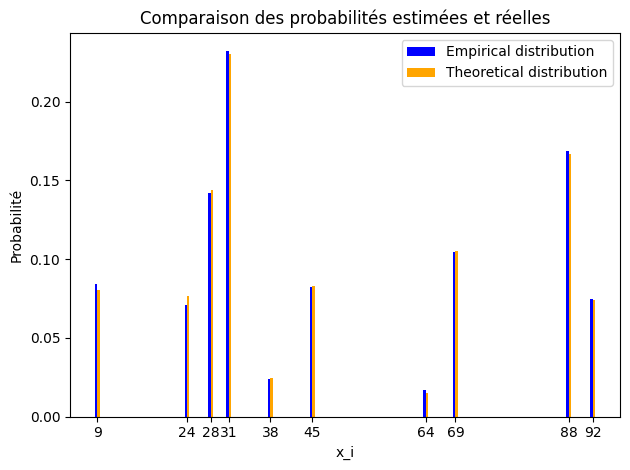

```python
# Générons n variables aléatoires qui suivent la loi de probabilité pi
n = 10000
X = []
for i in range(n):
    X.append(F_1(np.random.rand(), alpha_true, x_i))

extended_bins = np.append(x_i, [x_i[-1] + 1]) #Sert à résoudre le problème sur la probabilité de la dernière valeur
X = np.array(X)

hist, bins = np.histogram(X, bins=extended_bins)
estimated_alpha_true = hist / n
print("estimated_alpha_true", estimated_alpha_true)
print("alpha_true", alpha_true)
print("x_i", x_i)

plt.bar(x_i - 0.4/2, estimated_alpha_true, width=0.4, label='Empirical distribution', color='blue')
plt.bar(x_i + 0.4/2, alpha_true, width=0.4, label='Theoretical distribution', color='orange')

plt.xlabel('x_i')
plt.ylabel('Probabilité')
plt.title('Comparaison des probabilités estimées et réelles')
plt.xticks(x_i)
plt.legend()
plt.tight_layout()
plt.show()
```

On remarque que nos valeurs de probabilités estimées sont très proches des valeurs théoriques de probabilité.

# Exercise 2 : Gaussian mixture model and the EM algorithm

## Question 2 :

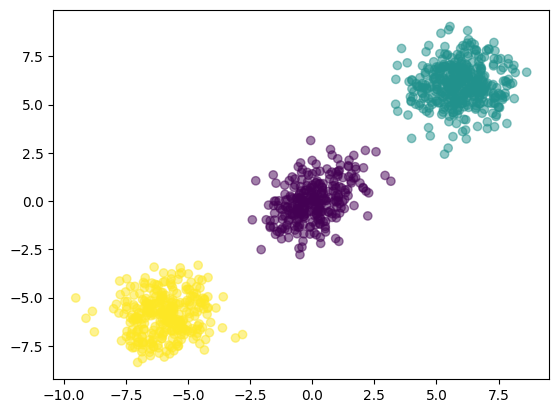

```python
# Prenons le cas où nous avons 3 clusters, p = 3
p = 3
d = 2
z_values = [1,2,3]
alpha_true = np.random.rand(p)
alpha_true = alpha_true/np.sum(alpha_true)
mu_i = np.array([[0,0], [6, 6], [-6, -6]]) #Je prends des valeurs espacées afin de bien pouvoir discerner les 3 gaussiennes
sigma_i = np.array([[[1,0.5],[0.5,1]], [[1, 0], [0, 1]], [[1, 0], [0, 1]]]) #Je prends des matrices de covariance classiques afin de bien pouvoir discerner les 3 gaussiennes




# Créons n tirages de la variable aléatoire Z qui peut prendre 3 valeurs [1,2,3] selon les probabilités alpha_true
n = 1000
Z = []
for i in range(n):
    Z.append(F_1(np.random.rand(), alpha_true, z_values))
Z = np.array(Z)

# Créons n tirages de la variable aléatoire X qui suit la loi normale N(mu_i, sigma_i) sachant la valeur de Z
X = []
for i in range(n):
    X.append(np.random.multivariate_normal(mu_i[Z[i]-1], sigma_i[Z[i]-1])) #On soustrait 1 car les indices commencent à 0
X = np.array(X)

plt.scatter(X[:,0], X[:,1], c=Z, cmap='viridis', alpha=0.5)
```

## Question 3 :

```python
def generate_random_sdp(d):
    """Génère une matrice symétrique définie positive aléatoire de taille d x d."""
    A = np.random.randn(d, d)  # Matrice aléatoire
    sdp_matrix = np.dot(A.T, A) + np.eye(d) * 1e-1  # A^T * A + petite matrice identité
    return sdp_matrix

def EM(X,p):
    n = len(X)
    d = len(X[0])
    #Initialisation
    #Il nous faut des valeurs aléatoires différentes pour les mu_j
    mu = np.random.rand(p, d)
    #Il nous faut des valeurs aléatoires différentes pour les sigma_j en respectant la condition de symétrie et de positivité définie
    sigma = np.array([generate_random_sdp(d) for _ in range(p)])
    #On initialise les probabilités alpha_j avec des valeurs aléatoires
    alpha = np.random.rand(p)
    alpha = alpha/np.sum(alpha)
    max_iter = 200
    epsilon = 0.01
    for _ in range(max_iter):
        #EXPECTATION
        tau=np.zeros((p,n))
        log_tau = np.zeros((p, n))
        for j in range(p):
            for i in range(n):
                log_tau[j, i] = np.log(alpha[j] + epsilon) - 0.5 * d * np.log(2 * np.pi) - 0.5 * np.log(np.linalg.det(sigma[j])) - 0.5 * (X[i] - mu[j]).dot(np.linalg.pinv(sigma[j])).dot((X[i] - mu[j])) #+ 1e-5
        logsum = logsumexp(log_tau, axis=0)
        tau = np.exp(log_tau - logsum)
        tau[np.isnan(tau)] = 0 #On remplace les valeurs nan par des 0

        #MAXIMISATION
        mu = np.zeros((p,d))
        sigma = np.zeros((p,d,d))
        alpha = np.zeros(p)
        sum_tau = np.sum(tau, axis=1)
        #On calcule les nouvelles valeurs de alpha_j
        alpha = sum_tau / np.sum(tau)
        alpha = alpha/np.sum(alpha) # On normalise alpha pour que la somme des alpha_j soit égale à 1

        sum_tau = np.sum(tau, axis=1)
        #On calcule les nouvelles valeurs de alpha_j
        for j in range(p):
            for i in range(n):
                mu[j] += tau[j,i]*X[i] #On calcule les nouvelles valeurs de mu_j
            mu[j] = mu[j]/sum_tau[j]
        for j in range(p):
            for i in range(n):
                sigma[j] += tau[j,i]* np.outer((X[i] - mu[j]),(X[i] - mu[j])) + np.eye(d) * epsilon #On calcule les nouvelles valeurs de sigma_j
            sigma[j] = sigma[j]/sum_tau[j]
    return alpha, mu, sigma

p=3
alpha, mu, sigma = EM(X,p)

print("alpha estimé:", alpha)
print("alpha réel:", alpha_true)

print("mu estimé:")
print(mu)
print("mu réel:")
print(mu_i)

print("sigma estimé:")
print(sigma)
print("sigma réel:")
print(sigma_i)
```

```
alpha estimé: [0.39799157 0.31699982 0.28500861]
alpha réel: [0.27526566 0.41227666 0.31245768]
mu estimé:
[[ 5.95551     6.01928759]
 [-5.95262185 -5.92169343]
 [ 0.04334014 -0.01512734]]
mu réel:
[[ 0  0]
 [ 6  6]
 [-6 -6]]
sigma estimé:
[[[1.01504163 0.05731493]
  [0.05731493 1.12583737]]

 [[1.04388066 0.10066563]
  [0.10066563 1.12813504]]

 [[0.95181962 0.43576803]
  [0.43576803 1.15895411]]]
sigma réel:
[[[1.  0.5]
  [0.5 1. ]]

 [[1.  0. ]
  [0.  1. ]]

 [[1.  0. ]
  [0.  1. ]]]
```

## Question 4 :

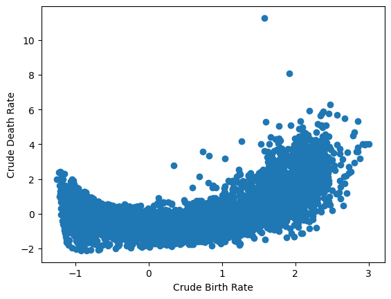

```python
file = "WPP2019_Period_Indicators_Medium.csv"
df = pd.read_csv(file)
df = df[["CDR", "CBR"]]
df = df.dropna()
mean = df.mean()
std = df.std()
df = (df-mean)/std
plt.scatter(df["CBR"], df["CDR"])
plt.ylabel("Crude Death Rate")
plt.xlabel("Crude Birth Rate")
X = df[["CDR", "CBR"]].to_numpy()
```

Les données montrent une structure complexe. La distribustion des données ne semble pas linéairment séparable. On peut identifier à priori plusieurs groupes d'agrégats avec des formes elliptiques. On peut alors penser qu'utiliser une mélange de gaussiennes ici pour représenter les données paraît adéquat.

## Question 5 :

```python
theta = {"alpha":[], "mu":[], "sigma":[]}
for p in tqdm(range(1, 8), desc="p"):
    alpha, mu, sigma = EM(X,p)
    theta["alpha"].append(alpha)
    theta["mu"].append(mu)
    theta["sigma"].append(sigma)
    print("mu:", mu)
```

```
mu: [[ 2.03570126e-16 -2.63913964e-16]]
```

```
mu: [[-0.21161612 -0.60771031]
 [ 0.42906821  1.23218012]]
```

```
mu: [[ 1.18830487  1.68486607]
 [ 0.02568702 -0.77713508]
 [-0.73413644  0.08532858]]
```

```
mu: [[-0.47007977  0.64327593]
 [-0.73250155 -0.11419915]
 [ 1.54376866  1.79135501]
 [ 0.06792126 -0.79653415]]
```

```
mu: [[-0.73138953 -0.12179442]
 [ 1.79687218  1.16660978]
 [ 0.06995009 -0.79782924]
 [ 1.46014942  1.77706233]
 [-0.50158015  0.60713913]]
```

```
mu: [[-0.05741317  0.66830788]
 [ 1.48788089  1.78391686]
 [ 0.06856089 -0.79745321]
 [-0.73422038 -0.11740559]
 [ 1.87163903  1.20433148]
 [-0.50020388  0.61351669]]
```

```
mu: [[ 0.06836569 -0.79761066]
 [ 1.90885072  1.26067839]
 [ 0.04147973  0.69493426]
 [-0.50254631  0.61256331]
 [ 1.49812802  1.78660182]
 [ 0.12648265  0.71498247]
 [-0.73436113 -0.11927897]]
```

```python
theta["alpha"]
```

```
[array([1.]),
 array([0.66970299, 0.33029701]),
 array([0.19779041, 0.46576079, 0.33644879]),
 array([0.15444336, 0.26251166, 0.15265111, 0.43039387]),
 array([0.2605968 , 0.00893171, 0.42660895, 0.15145753, 0.15240501]),
 array([0.0179002 , 0.14657029, 0.42601705, 0.25962071, 0.00815219,
        0.14173956]),
 array([0.42432947, 0.00764816, 0.0145292 , 0.13890474, 0.14276262,
        0.01316878, 0.25865704])]
```

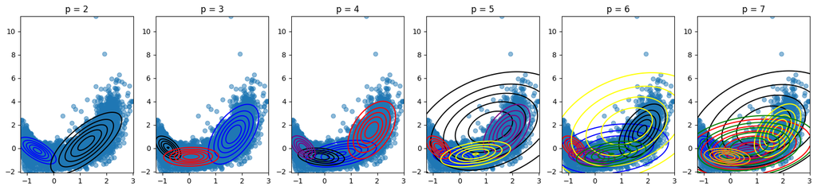

```python
def gaussian_density(x, mu, sigma):
    d = len(mu)
    return 1 / ((2 * np.pi)**(d / 2) * np.linalg.det(sigma)**0.5) * np.exp(-0.5 * (x - mu).dot(np.linalg.inv(sigma)).dot(x - mu))


fig, axes = plt.subplots(1, 6, figsize=(20, 4))
grid_x, grid_y = np.mgrid[min(X[:,0]):max(X[:,0]):100j, min(X[:,1]):max(X[:,1]):100j]
for u in range(2, 8):
    mu_p = theta["mu"][u-1]
    sigma_p = theta["sigma"][u-1]
    axes[u-2].scatter(X[:,1], X[:,0], cmap='viridis', alpha=0.5)
    Z = np.zeros(grid_x.shape)
    # Créons un contour plot pour chaque composante de la mixture d'une couleur différente
    colors = ['blue', 'black', 'red', 'purple', 'yellow', 'green', 'orange']
    for i in range(u):
        # On calcule la densité de la composante courante pour chaque point du grid
        Z_component = np.zeros_like(grid_x)
        for j in range(grid_x.shape[0]):
            for k in range(grid_x.shape[1]):
                x_point = np.array([grid_x[j, k], grid_y[j, k]])
                Z_component[j, k] = gaussian_density(x_point, mu_p[i], sigma_p[i])

        # Plot the contours for the current Gaussian density
        axes[u-2].contour(grid_y, grid_x, Z_component, levels=5, colors=colors[i])
        axes[u-2].set_title("p = " + str(u))
```

On remarque après visualisation de ces différents mélanges de gaussiennes, qu'à partir de p=5 il y a l'introduction de gaussiennes qui "chevauchent" toutes les autres, sans doute dans l'optique de pouvoir représenter les outliers. Si on prend en compte cette remarque, on peut donc penser que le mélange de gaussienne optimal serait pour p=4.  
Regardons maintenant si le Bayesian Information Criterion confirme cette hypothèse.

```python
def df(p):
    return 6*p -1

def log_vraisemblance(X, theta, p):
    alpha = theta["alpha"][p-1]
    mu = theta["mu"][p-1]
    sigma = theta["sigma"][p-1]
    n = len(X)
    d = len(X[0])
    l = 0
    for i in range (n):
        test = 0
        for j in range(p):
            test += alpha[j] / ((2*np.pi)**(d/2) * np.linalg.det(sigma[j])**(1/2)) * np.exp(-0.5 * (X[i] - mu[j]).dot(np.linalg.inv(sigma[j])).dot((X[i] - mu[j])))
        l += np.log(test)
    return l

def BIC(X, theta):
    minimum = np.inf
    p_min = 0
    for p in range(1, 8):
        test = df(p) * np.log(len(X))/2 - log_vraisemblance(X, theta, p)
        if minimum > test:
            minimum = test
            p_min = p
    return p_min

p_min = BIC(X, theta)
print("p_min", p_min)
```

[output not shown]

Le Bayesian Information Criterion confirme alors l'hypothèse que nous avions formulé. Affichons désormais le meilleur mélange de gaussiennes, au sens du BIC, sur nos données.

```python
alpha_p = theta["alpha"][p_min-1]
mu_p = theta["mu"][p_min-1]
sigma_p = theta["sigma"][p_min-1]

# Calculer les mu dénormalisés
mu_denormalized = np.empty_like(mu_p)
mu_denormalized = mu_p * std + mean

# Calculer les sigmas dénormalisés
sigma_p_denormalized = np.empty_like(sigma_p)
for k, sigma in enumerate(sigma_p):
    for i in range(sigma.shape[0]):
        for j in range(sigma.shape[1]):
            sigma_p_denormalized[k, i, j] = sigma[i, j] * std[i] * std[j]

# Calculer les X dénormalisés
X_denormalized = np.empty_like(X)
for i in range(X.shape[0]):
    for j in range(X.shape[1]):
        X_denormalized[i, j] = X[i, j] * std[j] + mean[j]
```

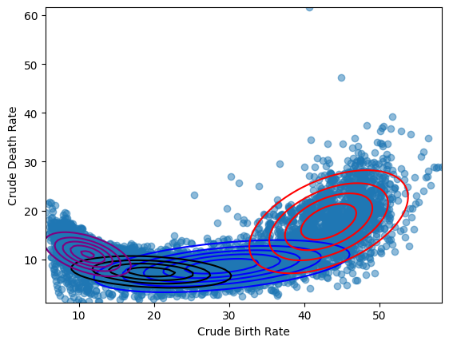

```python
plt.scatter(X_denormalized[:,1], X_denormalized[:,0], cmap='viridis', alpha=0.5)

Z = np.zeros(grid_x.shape)

grid_x, grid_y = np.mgrid[min(X_denormalized[:,0]):max(X_denormalized[:,0]):100j, min(X_denormalized[:,1]):max(X_denormalized[:,1]):100j]
colors = ['blue', 'black', 'red', 'purple']
for i in range(p_min):
    Z_component = np.zeros_like(grid_x)
    for j in range(grid_x.shape[0]):
        for k in range(grid_x.shape[1]):
            x_point = np.array([grid_x[j, k], grid_y[j, k]])
            Z_component[j, k] = gaussian_density(x_point, mu_denormalized[i], sigma_p_denormalized[i])

    plt.contour(grid_y, grid_x, Z_component, levels=5, colors=colors[i])

plt.ylabel("Crude Death Rate")
plt.xlabel("Crude Birth Rate")
plt.show()
```

### Exercise 3 : Importance sampling

### 3-A Poor importance sampling

## Question 1 :

```python
n = 1000

def p(x):
    return x**0.65 * np.exp(-x**2/2)

def q(x):
    return np.exp(-(0.8-x)**2/2)/np.sqrt(2*np.pi*1.5)

def f(x):
    return 2 * np.sin(2*np.pi*x/3)

def importance_sampling(n):
    # Générons n valeurs aléatoires suivant la loi normal N(0.8, 1.5)
    X = np.random.normal(0.8, 1.5, n)
    #Vérifions que tous les X_i sont bien positifs
    for i in range(n):
        while X[i] < 0:
            X[i] = np.random.normal(0.8, 1.5)
    weights_normalized = p(X)/q(X) / np.sum(p(X)/q(X))
    esperance = 1/n * np.sum(f(X) * weights_normalized)
    return esperance
esperance = importance_sampling(n)
print("Estimation de E_p[f(X)]:", esperance)
```

```
Estimation de E_p[f(X)]: 0.0004964051235655967
```

## Question 2 :

```python
Ns = [10, 100, 1000, 10000]
esperances = []

for N in Ns:
    esperances = [importance_sampling(N) for _ in range(100)]
    moyenne_esperances = np.mean(esperances)
    variance_esperances = np.var(esperances)
    print(f"Pour N={N}, Moyenne de l'estimation: {moyenne_esperances}, Variance de l'estimation: {variance_esperances}")
```

```
Pour N=10, Moyenne de l'estimation: 0.05069611956098941, Variance de l'estimation: 0.0023745423002229024
Pour N=100, Moyenne de l'estimation: 0.0053148031088937975, Variance de l'estimation: 1.7232848233004652e-06
Pour N=1000, Moyenne de l'estimation: 0.000544695271699419, Variance de l'estimation: 1.7366651488726422e-09
Pour N=10000, Moyenne de l'estimation: 5.420140997976712e-05, Variance de l'estimation: 1.724206372240916e-12
```

## Question 3 :

```python
def q(x, mu):
    return np.exp(-(mu-x)**2/2)/np.sqrt(2*np.pi*1.5)

def importance_sampling(n, mu):
    # Générons n valeurs aléatoires suivant la loi normal N(0.8, 1.5)
    X = np.random.normal(mu, 1.5, n)
    #Vérifions que tous les X_i sont bien positifs
    for i in range(n):
        while X[i] < 0:
            X[i] = np.random.normal(mu, 1.5)
    weights_normalized = p(X)/q(X, mu) / np.sum(p(X)/q(X, mu))
    esperance = 1/n * np.sum(f(X) * weights_normalized)
    return esperance, weights_normalized

Ns = [10, 100, 1000, 10000]
esperances = []

for N in Ns:
    esperances = [importance_sampling(N, 6)[0] for _ in range(100)]
    moyenne_esperances = np.mean(esperances)
    variance_esperances = np.var(esperances)
    print(f"Pour N={N}, Moyenne de l'estimation: {moyenne_esperances}, Variance de l'estimation: {variance_esperances}")
```

```
Pour N=10, Moyenne de l'estimation: 0.058667924287771386, Variance de l'estimation: 0.015085560284653124
Pour N=100, Moyenne de l'estimation: -0.007710395054266999, Variance de l'estimation: 0.0001310734148998352
Pour N=1000, Moyenne de l'estimation: 0.00041044807902220626, Variance de l'estimation: 1.2968084980469294e-06
Pour N=10000, Moyenne de l'estimation: 0.0001310226052871473, Variance de l'estimation: 1.4536257766099126e-09
```

```python
_, weights_q3 = importance_sampling(1000, 0.8)
_, weights_q3_6 = importance_sampling(1000, 6)
print("Poids d'importance normalisé, pour la moyenne 0.8", weights_q3[:10])
print("Poids d'importance normalisé, pour la moyenne 6", weights_q3_6[:10])
```

```
Poids d'importance normalisé, pour la moyenne 0.8 [0.00125352 0.0004137  0.00085776 0.00076707 0.00136857 0.00126147
 0.00100559 0.00096247 0.00109153 0.00051627]
Poids d'importance normalisé, pour la moyenne 6 [1.57698300e-14 5.70798291e-06 7.38477379e-04 4.30828232e-21
 1.21535766e-05 1.25267578e-14 1.04934469e-17 1.19679614e-14
 2.64777166e-06 1.98419104e-14]
```

On peut donc noter que les poids d'importances normalisés sont bien plus faibles pour la moyenne égale à 6 que pour la moyenne égale à 0.8. Par soucis de lisibilité, je n'ai affiché que les 10 premiers, mais c'est valable pour tous les autres aussi.

## Question 5 :

```python
def mixture_model_sample(theta, n_samples):
    """
    Fonction générant un sample selon un mélange de gaussiennes, c'est une généralisation de ce qui a été fait à la question 2 de l'exercice 2.

    """

    alpha = theta[0]
    mu = theta[1]
    sigma = theta[2]

    d = len(mu[0])
    # Grâce au code l'exercice 1 on peut générer un sample selon une loi multinomiale
    z_values = np.linspace(1, len(alpha), len(alpha))
    Z = []
    for i in range(n_samples):
        Z.append(F_1(np.random.rand(), alpha, z_values))
    Z = np.array(Z)

    samples = []
    # On calcule le nombre de samples à générer selon chaque gaussienne
    n_samples_per_component = [np.sum(Z == k) for k in range(1, len(alpha)+1)]

    # Pour chaque gaussienne on génère des samples selon la loi normale correspondante
    for i in range(len(alpha)):
        samples_component = np.random.multivariate_normal(mu[i], sigma[i] +np.eye(d) * 1e-6 , size=n_samples_per_component[i])
        samples.append(samples_component)

    # On regroupe tous les samples dans un seul array
    samples = np.vstack(samples)
    np.random.shuffle(samples)

    return samples

def banana_density(x, b, sigma_square):
    """
    Fonction calculant la densité de la distribution en banane en un point x.
    """

    d = len(x)

    mean = np.zeros(d)
    cov = np.diag([sigma_square] + [1] * (d - 1))

    new_x = x
    new_x[1] = new_x[1] + b * (x[0]**2 - sigma_square)

    density = 1 / ((2 * np.pi)**(d / 2) * np.linalg.det(cov)**0.5) * np.exp(-0.5 * (new_x - mean).dot(np.linalg.pinv(cov)).dot((new_x - mean)))

    return density

def mixture_model_density(x, theta):
    """
    Fonction calculant la densité d'un mélange de gaussiennes en un point x.

    """

    alpha = theta[0]
    mu = theta[1]
    sigma = theta[2]

    d = len(x)

    density = 0
    for i in range(len(alpha)):
        sigma_reg = sigma[i] + np.eye(d) * 1e-6
        component_density = 1 / ((2 * np.pi)**(d / 2) * np.linalg.det(sigma_reg)**0.5) * np.exp(-0.5 * (x - mu[i]).dot(np.linalg.pinv(sigma_reg)).dot(x - mu[i]))
        density += alpha[i] * component_density

    return density



def EM_weights(X, weights, p):
    """
    Algorithme EM de la question 4. les tau_ij ne dépendant pas des poids w_i, il suffit de calculer les nouveaux paramètres alpha_j, mu_j et sigma_j en utilisant les poids w_i.

    """
    n = len(X)
    d = len(X[0])
    #Initialisation
    #Il nous faut des valeurs aléatoires différentes pour les mu_j
    mu = np.random.rand(p, d)
    #Il nous faut des valeurs aléatoires différentes pour les sigma_j en respectant la condition de symétrie et de positivité définie
    sigma = np.array([generate_random_sdp(d) for _ in range(p)])
    #On initialise les probabilités alpha_j avec des valeurs aléatoires
    alpha = np.random.rand(p)
    alpha = alpha/np.sum(alpha)
    max_iter = 100
    epsilon = 1e-6
    for _ in range(max_iter):
        #EXPECTATION
        tau=np.zeros((p,n))
        log_tau = np.zeros((p, n))
        for j in range(p):
            for i in range(n):
                sigma_reg = sigma[j] + np.eye(d) * epsilon
                log_tau[j, i] = np.log(alpha[j]) - 0.5 * d * np.log(2 * np.pi) - 0.5 * np.log(np.linalg.det(sigma_reg)) - 0.5 * (X[i] - mu[j]).dot(np.linalg.pinv(sigma_reg)).dot((X[i] - mu[j])) + epsilon
        logsum = logsumexp(log_tau, axis=0)
        tau = np.exp(log_tau - logsum)
        tau[np.isnan(tau)] = 0 #On remplace les valeurs nan par des 0

        #MAXIMISATION
        mu = np.zeros((p,d))
        sigma = np.zeros((p,d,d))
        alpha = np.zeros(p)
        sum_tau = np.sum(tau, axis=1)

        # On calcule les nouveaux paramètres en utilisant les poids w_i, pour ça il suffit de multiplier les tau_ij par w_i
        tau = tau * weights[None, :]

        #On calcule les nouvelles valeurs de alpha_j
        alpha = sum_tau / np.sum(tau)
        alpha = alpha/np.sum(alpha) # On normalise alpha pour que la somme des alpha_j soit égale à 1

        sum_tau = np.sum(tau, axis=1)
        #On calcule les nouvelles valeurs de alpha_j
        for j in range(p):
            for i in range(n):
                mu[j] += tau[j,i]*X[i] #On calcule les nouvelles valeurs de mu_j
            mu[j] = mu[j]/sum_tau[j]
        for j in range(p):
            for i in range(n):
                sigma[j] += tau[j,i]* np.outer((X[i] - mu[j]),(X[i] - mu[j])) #On calcule les nouvelles valeurs de sigma_j
            sigma[j] = sigma[j]/sum_tau[j]
    return alpha, mu, sigma


def population_monte_carlo(n_samples, d, b, sigma_square):
    """
    Algorithme de la question 5.

    """

    # On initialise X selon une loi normale N(0, sigma)
    X = np.random.normal(0, np.sqrt(sigma_square), (n_samples, d))

    # On définit un certain nombre d'itérations max (on considèrera qu'il y a convergence si on atteint ce nombre d'itérations max)
    max_iterations = 100
    theta = EM(X, d)
    for _ in tqdm(range(max_iterations), desc="EM"):
        # On génère de nouvelles données X selon le mélange de gaussiennes défini par les paramètres theta de l'étape t
        X = mixture_model_sample(theta, n_samples)

        # On cherche les poids w_i de l'étape t+1 en utilisant les paramètres theta de l'étape t
        densities_mixture = np.array([mixture_model_density(x, theta) for x in X])
        densities_banana = np.array([banana_density(x, b, sigma_square) for x in X])
        weights = densities_banana / densities_mixture

        # On normalise les poids
        weights = weights / np.sum(weights)

        # On calcule les nouveaux paramètres theta t+1 en utilisant les poids w_i (cf question 4)
        theta = EM_weights(X, weights, d)

    return X
```

```python
samples = population_monte_carlo(500, d=5, b=0.4, sigma_square=1)
```

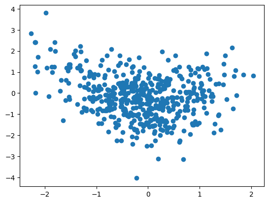

```python
plt.scatter(samples[:,0], samples[:,1])
```

On remarque qu'il n'y a pas assez de points pour l'affirmer mais on peut dire que les points générés grâce à l'algorithme Population Monte Carlo ont bien l'air de suivre la distribution en banane attendue. Du au long temps de calcul de cet algorithme, je ne tenterai pas d'afficher plus de points.